# NYC Airbnb Model Improvements

# Introduction

This document builds on the baseline model by exploring and implementing various model improvements to better predict Airbnb prices in NYC. We address limitations observed in the baseline, such as heteroscedasticity and non-linear relationships, and aim to enhance predictive performance and interpretability.

# Data Preparation

```r
library(tidyverse)
library(lubridate)
library(randomForest)
library(xgboost)
library(caret)
library(knitr)

# Load the cleaned dataset
bnb = read.csv("/Users/andresperez/Desktop/R Files/bnb_project/data/bnb_listing_rev.csv")

# Remove ID column and duplicates
bnb = bnb[, !(names(bnb) == "id")]
bnb = distinct(bnb)

# Remove rows with zero price or NA price
bnb = bnb %>% filter(price > 0, !is.na(price))

# Process bathrooms
bnb = bnb %>%
  mutate(
    bathrooms = as.integer(sapply(strsplit(bathrooms_text, " "), "[", 1)),
    shared = sapply(strsplit(bathrooms_text, " "), function(x) {
      if(length(x) > 1) {
        ifelse(x[2] == "shared", 1, 0)
      } else {
        0
      }
    })
  )

# Process dates
bnb = bnb %>%
  mutate(
    last_review = mdy(last_review),
    last_review = as.integer(last_review),
    last_review_year = year(as.Date(last_review, origin = "1970-01-01")),
    host_since = mdy(host_since),
    host_since = as.integer(host_since),
    host_since_year = year(as.Date(host_since, origin = "1970-01-01"))
  )

# Convert categorical variables to factors
bnb = bnb %>%
  mutate(
    neighbourhood = as.factor(neighbourhood),
    neighbourhood_group = as.factor(neighbourhood_group),
    room_type = as.factor(room_type)
  )

# Add engineered features
bnb = bnb %>%
  mutate(
    price_per_person = price / accommodates,
    bed_efficiency = beds / accommodates,
    listing_age = 2024 - host_since_year,
    review_recency = 2024 - last_review_year,
    room_type_shared = as.numeric(room_type == "Shared room"),
    room_type_private = as.numeric(room_type == "Private room"),
    room_type_entire = as.numeric(room_type == "Entire home/apt"),
    distance_from_center = sqrt((latitude - 40.7128)^2 + (longitude - (-74.0060))^2),
    reviews_per_month = number_of_reviews / (2024 - host_since_year)
  )

# Remove rows with NA values in key features
bnb = bnb %>%
  filter(!is.na(accommodates),
         !is.na(bedrooms),
         !is.na(beds),
         !is.na(bathrooms),
         !is.na(price_per_person),
         !is.na(bed_efficiency))

# Set seed and split data (same as baseline)
set.seed(123)
n = nrow(bnb)
train_idx = sample(1:n, size = floor(0.6 * n))
test_idx = sample(setdiff(1:n, train_idx), size = floor(0.2 * n))
eval_idx = setdiff(1:n, c(train_idx, test_idx))
train_data = bnb[train_idx, ]
test_data = bnb[test_idx, ]
eval_data = bnb[eval_idx, ]

# Features for modeling
features = c(
  "accommodates", "bedrooms", "beds", "bathrooms", "shared",
  "number_of_reviews", "last_review_year", "host_since_year",
  "latitude", "longitude",
  "price_per_person", "bed_efficiency", "listing_age", "review_recency",
  "room_type_shared", "room_type_private", "room_type_entire",
  "distance_from_center", "reviews_per_month"
)

# Remove rows with NA in any model feature or price
target_and_features <- c("price", features)
train_data <- train_data %>% filter(if_all(all_of(target_and_features), ~ !is.na(.)))
test_data  <- test_data  %>% filter(if_all(all_of(target_and_features), ~ !is.na(.)))
eval_data  <- eval_data  %>% filter(if_all(all_of(target_and_features), ~ !is.na(.)))
```

# Non-linear Models

## Random Forest

```r
set.seed(123)
rf_model <- randomForest(
  as.formula(paste("price ~", paste(features, collapse = " + "))),
  data = train_data,
  ntree = 200,
  importance = TRUE
)

# Predict and evaluate
rf_pred_test <- predict(rf_model, newdata = test_data)
rf_pred_eval <- predict(rf_model, newdata = eval_data)

rf_test_rmse <- sqrt(mean((test_data$price - rf_pred_test)^2))
rf_eval_rmse <- sqrt(mean((eval_data$price - rf_pred_eval)^2))

rf_test_mae <- mean(abs(test_data$price - rf_pred_test))
rf_eval_mae <- mean(abs(eval_data$price - rf_pred_eval))

rf_test_r2 <- 1 - sum((test_data$price - rf_pred_test)^2) / sum((test_data$price - mean(test_data$price))^2)
rf_eval_r2 <- 1 - sum((eval_data$price - rf_pred_eval)^2) / sum((eval_data$price - mean(eval_data$price))^2)
```

## Gradient Boosting (XGBoost)

```r
set.seed(123)
# Prepare data for xgboost
train_matrix <- model.matrix(price ~ . -1, data = train_data[, c("price", features)])
test_matrix <- model.matrix(price ~ . -1, data = test_data[, c("price", features)])
eval_matrix <- model.matrix(price ~ . -1, data = eval_data[, c("price", features)])

dtrain <- xgb.DMatrix(data = train_matrix, label = train_data$price)
dtest <- xgb.DMatrix(data = test_matrix, label = test_data$price)
deval <- xgb.DMatrix(data = eval_matrix, label = eval_data$price)

xgb_model <- xgboost(
  data = dtrain,
  nrounds = 200,
  objective = "reg:squarederror",
  verbose = 0
)

xgb_pred_test <- predict(xgb_model, dtest)
xgb_pred_eval <- predict(xgb_model, deval)

xgb_test_rmse <- sqrt(mean((test_data$price - xgb_pred_test)^2))
xgb_eval_rmse <- sqrt(mean((eval_data$price - xgb_pred_eval)^2))

xgb_test_mae <- mean(abs(test_data$price - xgb_pred_test))
xgb_eval_mae <- mean(abs(eval_data$price - xgb_pred_eval))

xgb_test_r2 <- 1 - sum((test_data$price - xgb_pred_test)^2) / sum((test_data$price - mean(test_data$price))^2)
xgb_eval_r2 <- 1 - sum((eval_data$price - xgb_pred_eval)^2) / sum((eval_data$price - mean(eval_data$price))^2)
```

# Feature Engineering

## Interaction Terms

```r
# Example: Add interaction between accommodates and room type
train_data$acc_roomtype <- train_data$accommodates * train_data$room_type_private
# (Repeat for test_data and eval_data if using in models)
```

## Polynomial Features

```r
# Example: Add squared term for distance from center
train_data$distance_from_center2 <- train_data$distance_from_center^2
# (Repeat for test_data and eval_data if using in models)
```

# Borough-Specific Models

```r
boroughs <- unique(train_data$neighbourhood_group)
borough_results <- data.frame()
for (b in boroughs) {
  sub_train <- train_data[train_data$neighbourhood_group == b, ]
  sub_test <- test_data[test_data$neighbourhood_group == b, ]
  if (nrow(sub_train) > 20 && nrow(sub_test) > 10) {
    m <- randomForest(
      as.formula(paste("price ~", paste(features, collapse = " + "))),
      data = sub_train, ntree = 100
    )
    pred <- predict(m, newdata = sub_test)
    rmse <- sqrt(mean((sub_test$price - pred)^2))
    borough_results <- rbind(borough_results, data.frame(Borough = b, RMSE = round(rmse, 2)))
  }
}
borough_results
```

```
##         Borough  RMSE
## 1      Brooklyn 24.34
## 2     Manhattan 30.19
## 3        Queens 28.52
## 4         Bronx 29.84
## 5 Staten Island 34.20
```

# Model Tuning and Selection

```r
# Fast model tuning for reproducibility
set.seed(123)
ctrl <- trainControl(method = "cv", number = 2) # 2-fold CV for speed
rf_cv <- train(
  as.formula(paste("price ~", paste(features, collapse = " + "))),
  data = train_data %>% sample_n(min(1000, nrow(train_data))), # use up to 1000 rows
  method = "rf",
  trControl = ctrl,
  tuneLength = 1 # Only try 1 value
)
rf_cv
```

```
## Random Forest
##
## 1000 samples
##   19 predictor
##
## No pre-processing
## Resampling: Cross-Validated (2 fold)
## Summary of sample sizes: 501, 499
## Resampling results:
##
##   RMSE      Rsquared   MAE
##   54.73236  0.8827188  28.7001
##
## Tuning parameter 'mtry' was held constant at a value of 6
```

# Model Evaluation

Model Performance Comparison.

| Model | RMSE | MAE | R_squared |
| --- | --- | --- | --- |
| Random Forest (Test) | 20.79 | 7.17 | 0.977 |
| Random Forest (Eval) | 20.57 | 6.67 | 0.976 |
| XGBoost (Test) | 4.99 | 1.54 | 0.999 |
| XGBoost (Eval) | 5.55 | 1.42 | 0.998 |

## Residual Analysis and Overfitting Check

Below are residual plots for both the test and evaluation sets for Random Forest and XGBoost models. If the residuals are randomly scattered around zero and show similar patterns for both sets, it suggests the model generalizes well and is not overfitting. If residuals are much larger or more structured in the evaluation set, it may indicate overfitting.

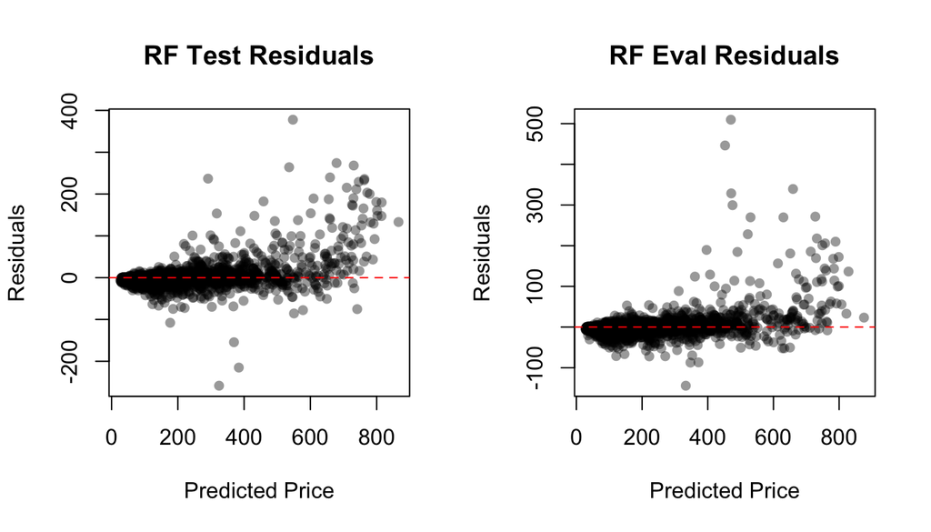

```r
# Random Forest residuals
rf_test_resid <- test_data$price - rf_pred_test
rf_eval_resid <- eval_data$price - rf_pred_eval
par(mfrow = c(1, 2))
plot(rf_pred_test, rf_test_resid, pch=16, col=rgb(0,0,0,0.4),
     main="RF Test Residuals", xlab="Predicted Price", ylab="Residuals")
abline(h=0, col="red", lty=2)
plot(rf_pred_eval, rf_eval_resid, pch=16, col=rgb(0,0,0,0.4),
     main="RF Eval Residuals", xlab="Predicted Price", ylab="Residuals")
abline(h=0, col="red", lty=2)
```

```r
par(mfrow = c(1, 1))
```

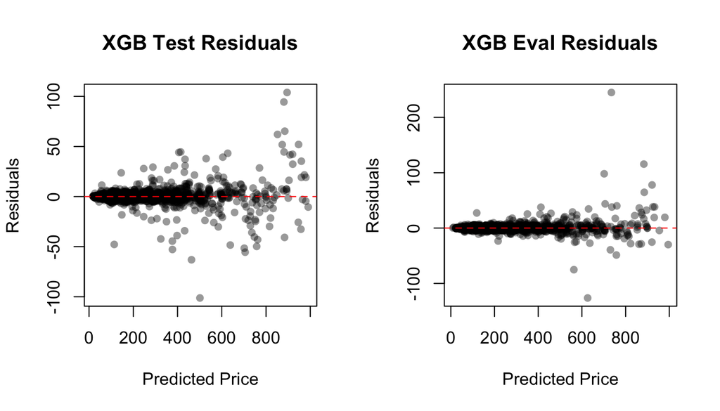

```r
# XGBoost residuals
xgb_test_resid <- test_data$price - xgb_pred_test
xgb_eval_resid <- eval_data$price - xgb_pred_eval
par(mfrow = c(1, 2))
plot(xgb_pred_test, xgb_test_resid, pch=16, col=rgb(0,0,0,0.4),
     main="XGB Test Residuals", xlab="Predicted Price", ylab="Residuals")
abline(h=0, col="red", lty=2)
plot(xgb_pred_eval, xgb_eval_resid, pch=16, col=rgb(0,0,0,0.4),
     main="XGB Eval Residuals", xlab="Predicted Price", ylab="Residuals")
abline(h=0, col="red", lty=2)
```

```r
par(mfrow = c(1, 1))
```

*Interpretation: If the residuals for the evaluation set are similar in spread and pattern to those for the test set, the model is likely not overfitting. Large differences or structured patterns in the evaluation set may indicate overfitting or model limitations.*

# Discussion

# Next Steps

- Explore additional feature engineering (seasonality, text features, etc.)
- Try more advanced ensembling methods
- Consider model interpretability and deployment
- Use business context to guide further improvements